# GlobalGeoTree Dataset Analysis

Exploring source bias, temporal trends, and regional patterns in a global tree observation dataset

Author

GlobalGeoTree team

Published

17 July 2026

# 1 Introduction

*Authors: Nataliia (source bias, temporal development & Germany analysis), Anna (data structure & taxonomic composition), Camille (worldwide distribution), Santiago (US analysis)*

*— Nataliia*

This report analyses the GlobalGeoTree dataset, a global collection of more than 6 million georeferenced tree observations covering species, taxonomic groups, and geographical locations of trees combined from several sources from across the world.

This dataset was originally published in the paper ‘GlobalGeoTree: A Multi-Granular Vision-Language Dataset for Global Tree Species Classification’ (Mu et al., 2025).

GlobalGeoTree was assembled from existing datasets rather than from a new field survey. The authors combined tree-species lists from TreeGOER, GlobalTreeSearch, and other open sources, then standardised the taxonomy with the GBIF Species API. This produced an initial catalogue of 87,845 possible tree species.

For these species, the authors downloaded georeferenced occurrence records from GBIF — Global Biodiversity Information Facility. They kept openly licensed human observations from 2015–2024, removed duplicates and records with location problems, and excluded observations outside areas classified as forest (Mu et al., 2025).

The high-level goals of our project were to identify the sources of this dataset, examine how those sources are distributed, assess geographic and source-related biases, evaluate how well different regions are represented, and explore whether the data can support practical tree-related applications.

The report is organised in three main parts.

**Part I** examines global patterns: which sources dominate the dataset and how they shape what we see, how observations have changed over time, and how taxonomic composition and species richness vary across the world.

**Part II** zooms into Germany as a whole and then Berlin in detail.

**Part III** examines the United States, the most-represented country in the dataset, analysing species composition and geographic patterns at the national level.

```r
# ── Setup ────────────────────────────────────────────────────

# Packages are loaded below; inline comments note their role in the report.

library(data.table)     # fast CSV loading with fread()
library(dplyr)          # filtering, grouping, joins, summaries
library(ggplot2)        # charts and map visualisations
library(ggridges)       # ridge-density plot by latitude
library(jsonlite)       # GBIF common-name API calls
library(knitr)          # kable summary tables
library(maps)           # world/state polygons for map_data()
library(purrr)          # map_dfr() in rarefaction analysis
library(rnaturalearth)  # world country boundaries
library(scales)         # readable numbers and percentages
library(sf)             # spatial objects, boundaries, joins
library(stringr)        # source classification and labels
library(tibble)         # tidy data frames and rowname helpers
library(tidyr)          # pivoting data for plots and matrices
library(vegan)          # rarefaction curves

set.seed(42)
sf::sf_use_s2(FALSE)
options(knitr.kable.NA = ' ')
options(viewer = NULL)
```

```r
# ── Global analysis config ────────────────────────────────────────────────────

# The following variables define the dataset year bounds and how many items appear in rankings and maps.

start_year <- 2015
end_year   <- 2024

map_sample_seed <- 42
world_map_sample_n <- 40000L
us_map_sample_n <- 50000L
density_map_sample_n <- 50000L

top_n_sources     <- 10
top_n_countries   <- 15
top_n_taxa        <- 12
top_n_source_maps <- 4

snapshot_years <- c(2015, 2018, 2021, 2024)
period_levels <- c("2015–2016", "2017–2018", "2019–2020", "2021–2022", "2023–2024")
source_map_sample_n <- 50000L
```

# 2 Methodology

This section explains the analytical choices that we implemented throughout the project.

**Data scope.** Rows with missing country codes or species names are removed during loading. Coordinates are converted to numeric values and validated before the continent spatial join; records with missing or out-of-range coordinates, unmatched continents, or open-ocean assignments are excluded from the spatially analysed dataset.

**Source classification.** Each observation carries a free-text source field with thousands of distinct values. A keyword-matching function (`classify_source()`) assigns each source name to one of six groups: iNaturalist, Pl@ntNet, Other citizen-science apps, Institutional & survey data, Reference & thematic databases, and Other / unknown. The rules are applied in order, and the first match wins. This approach works well for English-language source names and major platforms but can misclassify source names in other languages or those using project-specific abbreviations. The “Other / unknown” group is a catch-all for everything that did not match any rule. This approach is demonstrated in the corresponding report section.

**Geographic boundaries.** For the Germany analysis, administrative boundaries at the NUTS1 level — the federal states (Bundesländer) — and the NUTS3 level (districts) are loaded from GISCO, the geographic information system of the European Commission. Berlin local-area boundaries come from a separate open-data project, listed under sources. If a local copy of these files exists, it is used directly; otherwise the file is downloaded from the public URL on first render.

**Visualisation and subsampling.** The dataset contains more than 6 million observations, so plotting every record would be slow, produce very large files, and add little visual value. Point-based maps therefore use reproducible random subsamples with a fixed seed of 42. Global maps display up to 40,000 observations, while source-specific and density maps use up to 50,000 records per group or map. US and Germany maps use region-specific limits; for Germany, the dataset is often small enough that all observations can be shown. The sampling affects only the visualisations. All counts, rankings, species-richness tables, rarefaction analyses, and source summaries use the full relevant dataset.

# Part I: Global Patterns

# 3 Data Preparation

## 3.1 Data Loading and Cleaning

The CSV file was loaded using `fread()`, which is designed to handle large datasets efficiently.

The text fields were cleaned by removing extra spaces, and columns such as coordinates and years were converted into the correct numeric format.

Records without a country code or species name were excluded.

The coordinates were matched to a world map to identify the continent of each observation.

Two manual corrections were added: Russia was divided at 60°E between Europe and Asia, and Réunion was assigned to Africa.

```r
raw <- fread(observations_path, showProgress = FALSE)

df <- raw |>
  mutate(
    source_raw   = ifelse(
      is.na(source) | str_trim(source) == "",
      "unknown source",
      str_trim(source)
    ),
    source_group = factor(classify_source(source_raw), levels = source_group_levels),
    country_code = str_to_upper(str_trim(country_code)),
    level3_species = str_trim(level3_species),
    level1_family  = str_trim(level1_family),
    level2_genus   = str_trim(level2_genus),
    year      = as.integer(year),
    latitude  = suppressWarnings(as.numeric(latitude)),
    longitude = suppressWarnings(as.numeric(longitude))
  ) |>
  filter(
    !is.na(country_code), country_code != "",
    !is.na(level3_species), level3_species != ""
  )

rm(raw)
```

```r
# Validate coordinates before converting rows to spatial features. Records that
# cannot be assigned spatially would otherwise fail here and are excluded later
# in any case because the report requires a continent assignment.
df <- valid_map_points(df)

coords_unique <- df |>
  distinct(longitude, latitude)

points <- st_as_sf(coords_unique,
                   coords = c("longitude", "latitude"),
                   crs = 4326)

world <- ne_countries(scale = "small", returnclass = "sf")

coords_unique$continent <- st_join(points, world["continent"])$continent

df <- df |>
  left_join(coords_unique, by = c("longitude", "latitude"))
rm(points, coords_unique)

df <- df %>%
  mutate(
    continent = case_when(
      location == "Russian Federation" & longitude < 60 ~ "Europe",
      location == "Russian Federation" & longitude >= 60 ~ "Asia",
      location == "Réunion" & latitude < -20 ~ "Africa",
      TRUE ~ continent
    )
  )

df <- df[!is.na(df$continent), ]
df <- df[df$continent != "Seven seas (open ocean)", ]

data <- df

df_world_map_base <- valid_map_points(df)

df_world_map_sample <- sample_up_to(df_world_map_base, world_map_sample_n)

df_world_map_sample_by_level0 <- df_world_map_base |>
  filter(!is.na(level0), level0 != "") |>
  group_by(level0) |>
  group_modify(~ sample_up_to(.x, world_map_sample_n)) |>
  ungroup()

df_world_map_sample_by_period <- df_world_map_base |>
  mutate(
    periode = case_when(
      year %in% c(2015, 2016) ~ "2015–2016",
      year %in% c(2017, 2018) ~ "2017–2018",
      year %in% c(2019, 2020) ~ "2019–2020",
      year %in% c(2021, 2022) ~ "2021–2022",
      year %in% c(2023, 2024) ~ "2023–2024"
    ),
    periode = factor(periode, levels = period_levels)
  ) |>
  filter(!is.na(periode)) |>
  group_by(periode) |>
  group_modify(~ sample_up_to(.x, world_map_sample_n)) |>
  ungroup()
```

```r
data_summary <- tibble(
  Measure = c(
    "Observation file", "Dataset period", "Rows analysed",
    "Distinct sources", "Distinct source groups", "Distinct countries",
    "Distinct species", "Germany rows"
  ),
  Value = c(
    observations_path,
    paste(start_year, end_year, sep = "–"),
    format_number(nrow(df)),
    format_number(n_distinct(df$source_raw)),
    format_number(n_distinct(df$source_group)),
    format_number(n_distinct(df$country_code)),
    format_number(n_distinct(df$level3_species)),
    format_number(sum(df$country_code == "DE"))
  )
)
nice_table(data_summary)
```

| Measure | Value |
| --- | --- |
| Observation file | data/GlobalGeoTree.csv |
| Dataset period | 2015–2024 |
| Rows analysed | 5,843,499 |
| Distinct sources | 2,397 |
| Distinct source groups | 6 |
| Distinct countries | 165 |
| Distinct species | 20,446 |
| Germany rows | 203,728 |

The table above confirms that the dataset loaded correctly and gives an overview of its scope. The analysis uses 5,843,499 observations in total.

## 3.2 Dataset Overview

*— Anna*

| Column | Description |
| --- | --- |
| `sample_id` | Entry ID |
| `country_code` | Code of the country (e.g. US for the USA) |
| `level0` | Broad vegetation category grouping plants by shared ecological and physiological traits (e.g. Evergreen Broadleaf) |
| `level1_family` | Taxonomic Family — a group of related genera sharing common evolutionary characteristics (e.g. Asphodelaceae) |
| `level2_genus` | Taxonomic Genus — a group of closely related species (e.g. Aloe) |
| `level3_species` | Taxonomic Species — the most specific classification level (e.g. Aloe africana) |
| `location` | Country name |
| `source` | Source from which the occurrence record was obtained (e.g. iNaturalist Research-grade Observations) |
| `species_key` | Species identifier |
| `year` | Year of the observation |
| `longitude` | Geographic longitude |
| `latitude` | Geographic latitude |

## 3.3 Distribution of the data across the world

Data distribution across the different countries:

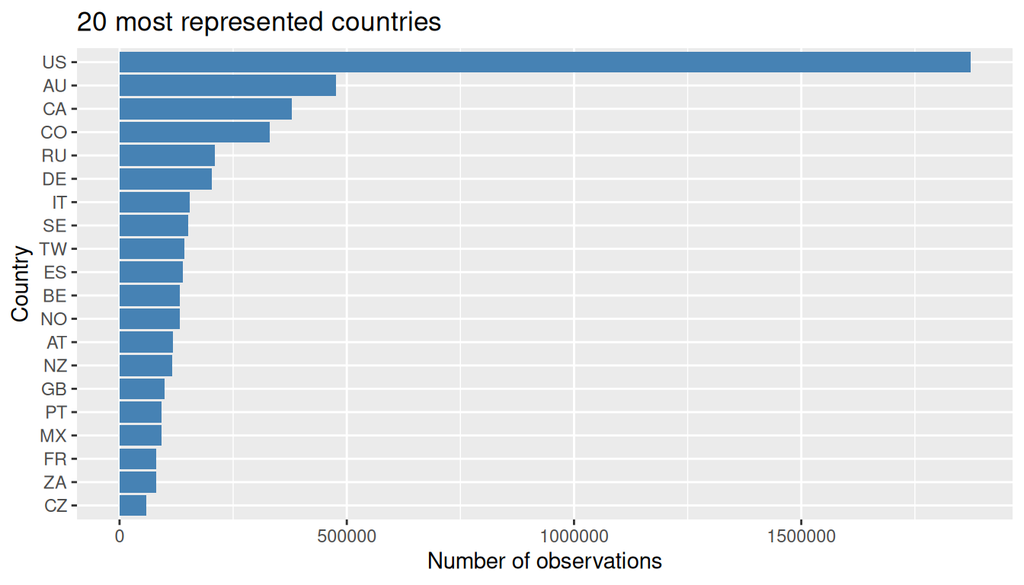

```r
# Count for each country
country_counts <- data %>% count(country_code, sort = TRUE)
# Histogram of the 20 first countries only

country_counts %>% slice_max(n, n = 20) %>% ggplot(aes(x = reorder(country_code, n), y = n)) + geom_col(fill = "steelblue") + coord_flip() + plot_labs( x = "Country", y = "Number of observations", title = "20 most represented countries" )
```

We see that most of the data comes from developed western countries, and especially from the US, which has a very large number of observations compared to the other countries.

Therefore the following research questions arise: is there any evolution of the data collected throughout the years? Do some countries present large imbalance in the data distribution? How could this affect our analysis?

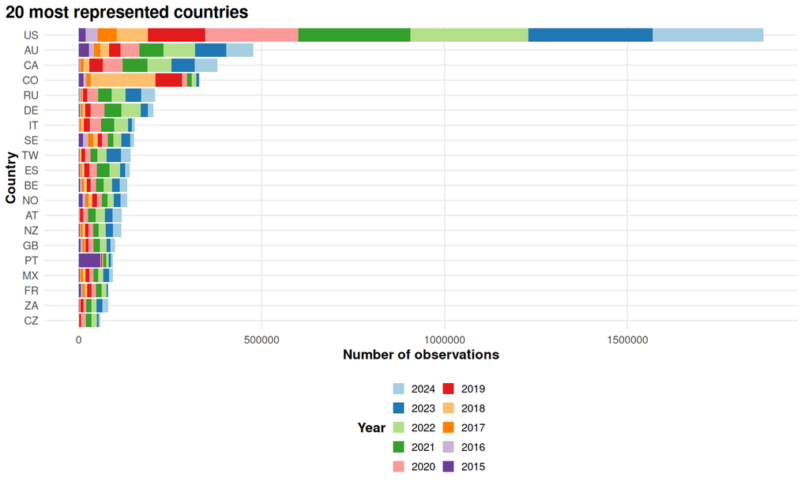

```r
top20_countries <- data %>% count(country_code, sort = TRUE) %>% slice_head(n = 20)

# Counting of every data for each country per year count(country_code, year)
country_year_counts <- data %>%
  filter(country_code %in% top20_countries$country_code) %>%
  count(country_code, year)

# Order the years : recent -> old
country_year_counts$year <- factor(
  country_year_counts$year,
  levels = sort(unique(country_year_counts$year), decreasing = TRUE)
)

ggplot(country_year_counts, aes(x = reorder(country_code, n, FUN = sum), y = n, fill = year)) + geom_col() + coord_flip() + scale_fill_brewer(palette = "Paired") + plot_labs( x = "Country", y = "Number of observations", fill = "Year", title = "20 most represented countries" ) + theme_gtree() + theme(legend.key.size = unit(0.4, "cm")) + guides(fill = guide_legend(ncol = 2))
```

The graph shows that observations across different countries were collected over a ten-year period. To understand these records in more depth, we analyse their data sources and examine the worldwide distribution of observations in the dataset.

# 4 Source and Platform Bias

*— Nataliia*

In this section of the report we were trying to answer the following research questions:

- *How many distinct sources are in the dataset, and how can they be grouped?*
- *Is the dataset dominated by a few platforms, or do many sources contribute evenly?*
- *What does source concentration mean for the rest of the analysis?*

This section starts from the raw `source` column in the dataset and works outwards: first what the column actually contains, then how its thousands of names can be grouped, which sources contribute the most observations, how source composition varies by country and plant family, and finally whether different sources leave distinct geographic footprints.

## 4.1 Exploring the Raw Source Field

The `source` column contains free-text entries. The dataset does not specify how many providers contributed records, what types of organisations they are, or whether the same platform is always written in the same way.

Because all later analysis in this section depends on these details, the source field is examined first, before any comparisons are made.

```r
# Count every distinct spelling of the source field, including the ones that no
# classification rule will later match. This is deliberately unfiltered: the
# question here is what the raw field contains, not what we can make sense of.
source_raw_counts <- df |>
  count(source_raw, sort = TRUE, name = "observations") |>
  mutate(
    share            = observations / sum(observations),
    cumulative_share = cumsum(share),
    source_rank      = row_number()
  )

n_sources_total <- nrow(source_raw_counts)
share_top10     <- sum(source_raw_counts$share[seq_len(min(10, n_sources_total))])
n_sources_rare  <- sum(source_raw_counts$observations < 100)
share_rare      <- sum(source_raw_counts$share[source_raw_counts$observations < 100])
```

The field contains **2,397 distinct source names** across 5,843,499 observations. They are not evenly sized: the ten largest names alone account for **88.4%** of all observations, while 2,052 names contribute fewer than 100 observations each and together make up just 0.5% of the data.

```r
source_size_profile <- source_raw_counts |>
  mutate(
    size_class = cut(
      observations,
      breaks = c(0, 100, 1000, 10000, 100000, Inf),
      labels = c("< 100", "100 – 999", "1,000 – 9,999", "10,000 – 99,999", "≥ 100,000"),
      right  = FALSE
    )
  ) |>
  group_by(size_class) |>
  summarise(
    sources      = n(),
    observations = sum(observations),
    .groups      = "drop"
  ) |>
  mutate(share = observations / sum(observations)) |>
  arrange(desc(size_class)) |>
  transmute(
    `Observations per source` = size_class,
    `Distinct sources`        = format_number(sources),
    `Observations`            = format_number(observations),
    `Share of observations`   = format_percent(share)
  )

nice_table(source_size_profile)
```

| Observations per source | Distinct sources | Observations | Share of observations |
| --- | --- | --- | --- |
| ≥ 100,000 | 7 | 4,930,405 | 84.4% |
| 10,000 – 99,999 | 16 | 559,024 | 9.6% |
| 1,000 – 9,999 | 83 | 257,080 | 4.4% |
| 100 – 999 | 239 | 70,571 | 1.2% |
| < 100 | 2,052 | 26,419 | 0.5% |

This is the main problem: a small number of very large sources provide most observations of the dataset, while hundreds of smaller sources provide only a very small part of it. Therefore, an analysis should not assume that all sources contribute equally. Doing so would focus too much on the many small sources, even though the few large sources have the greatest influence on the results.

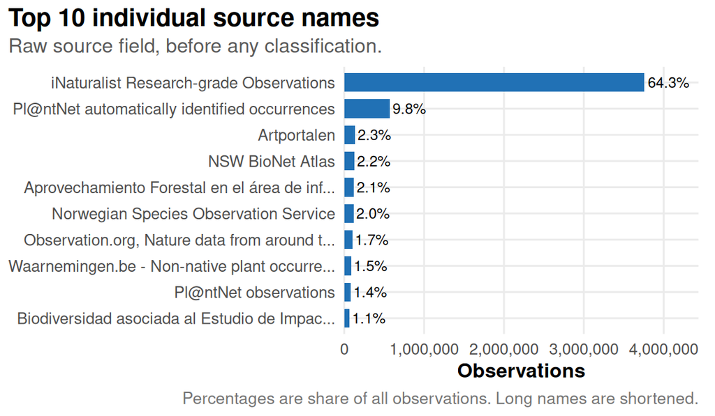

```r
top_sources_raw <- source_raw_counts |>
  slice_head(n = top_n_sources) |>
  mutate(source_short = reorder(str_trunc(source_raw, 45), observations))

ggplot(top_sources_raw, aes(x = source_short, y = observations)) +
  geom_col(fill = "#2171B5", width = 0.72) +
  geom_text(aes(label = format_percent(share)), hjust = -0.08, size = 3.1) +
  coord_flip(clip = "off") +
  scale_y_continuous(labels = comma, expand = expansion(mult = c(0, 0.18))) +
  plot_labs(
    title    = paste0("Top ", top_n_sources, " individual source names"),
    subtitle = "Raw source field, before any classification.",
    x = NULL, y = "Observations",
    caption  = "Percentages are share of all observations. Long names are shortened."
  ) +
  theme_gtree()
```

Reading the actual names is what makes the grouping possible. The most common sources belong to several recurring provider types: two global identification apps, several national observation portals, an aggregator category, forest inventory databases, and floristic archives.

The same provider may appear under different spellings, and some source names are written in languages other than English. Both issues affect the classification method explained in the next section.

## 4.2 Source Classification

### 4.2.1 From Raw Names to Source Groups

The 2,397 distinct source names are too numerous to compare individually. Grouping them makes broader questions answerable, such as whether a pattern is linked to citizen-science apps or formal surveys, although some detail is lost within each group.

The groups were derived from the source names rather than defined in advance. The ten most frequent names already account for 88.4% and revealed several recurring provider types. Each type became a group, identified through keywords. The `classify_source()` function applies these rules in order, assigns the first match, and uses a final catch-all category.

Keyword matching is more practical than exact matching because provider names are often inconsistent, for example “iNaturalist”, “iNat”, and “iNaturalist Research-grade Observations”. It also avoids manually listing the 2,052 rare names.

**GBIF is not one of the groups, even though it is the aggregator every record passed through.** The authors downloaded the entire dataset from GBIF, so the `source` field names the underlying dataset that GBIF redistributes — “iNaturalist Research-grade Observations”, “EOD – eBird Observation Dataset” — and never GBIF itself.

**“Other / unknown”** should not be treated as fully unclassifiable. Multilingual names and project codes may fail to match rules based mainly on English-language terms. The category is therefore examined further rather than discarded.

The resulting six groups (ordered from most to least specific):

- **iNaturalist** — the largest citizen-science biodiversity platform worldwide.
- **Pl@ntNet** — a plant-identification app with a stronger presence in French-speaking countries and the Global South.
- **Other citizen-science apps** — regional portals (e.g., Artportalen, iRecord, Naturgucker, NatureMapr).
- **Institutional & survey data** — herbarium/museum collections and systematic field campaigns.
- **Reference & thematic databases** — compiled floristic atlases, global plant databases (e.g., BIEN, RAINBIO, Tropicos), Wikidata, and invasive-species tracking.
- **Other / unknown** — everything that did not match any keyword rule.

The table below shows the rules themselves, in the order `classify_source()` evaluates them, together with the largest source names each rule actually captures. The examples are read from the data rather than written by hand, so they stay accurate if the rules or the dataset change.

```r
# Two largest real source names per group, so the reader can check the rules
# against what they actually matched.
source_rule_examples <- df |>
  mutate(source_group = as.character(source_group)) |>
  count(source_group, source_raw, sort = TRUE, name = "observations") |>
  group_by(source_group) |>
  slice_head(n = 2) |>
  summarise(
    Examples = paste(str_trunc(source_raw, 38), collapse = "; "),
    .groups  = "drop"
  )

# Rule order mirrors classify_source() and is hand-written: "first match wins"
# is only readable if the table follows evaluation order.  Keep both in sync —
# nothing enforces it.
source_rules <- tibble(
  Order = 1:6,
  `Keyword rule (abridged)` = c(
    "inaturalist, inat",
    "plantnet, pl@ntnet",
    "artportalen, observation.org, naturgucker, irecord, …",
    "herbar, museum, botanic, inventory, survey, monitoring, …",
    paste0(
      "atlas, flora, bien, rainbio, tropicos, wikidata, invasive, ",
      "aprovechamiento forestal, impacto ambiental, …"
    ),
    "— no rule matched —"
  ),
  source_group = c(
    "iNaturalist", "Pl@ntNet",
    "Other citizen-science apps", "Institutional & survey data",
    "Reference & thematic databases", "Other / unknown"
  )
) |>
  left_join(source_rule_examples, by = "source_group") |>
  rename(`Assigned group` = source_group, `Example matched sources` = Examples)

nice_table(source_rules)
```

| Order | Keyword rule (abridged) | Assigned group | Example matched sources |
| --- | --- | --- | --- |
| 1 | inaturalist, inat | iNaturalist | iNaturalist Research-grade Observat…; ““Flora of Russia”” on iNaturalist:… |
| 2 | plantnet, pl@ntnet | Pl@ntNet | Pl@ntNet automatically identified o…; Pl@ntNet observations |
| 3 | artportalen, observation.org, naturgucker, irecord, … | Other citizen-science apps | Artportalen; Norwegian Species Observation Service |
| 4 | herbar, museum, botanic, inventory, survey, monitoring, … | Institutional & survey data | Forestry Inventory 2015; Danish government nature monitoring… |
| 5 | atlas, flora, bien, rainbio, tropicos, wikidata, invasive, aprovechamiento forestal, impacto ambiental, … | Reference & thematic databases | NSW BioNet Atlas; Aprovechamiento Forestal en el área… |
| 6 | — no rule matched — | Other / unknown | EOD – eBird Observation Dataset; SA Flora |

### 4.2.2 Classification coverage

```r
coverage_stats <- df |>
  summarise(
    total        = n(),
    n_other      = sum(source_group == "Other / unknown"),
    n_classified = total - n_other,
    coverage     = n_classified / total,
    other_rate   = n_other / total
  )
```

Of all 5,843,499 observations, **97.3%** are assigned to one of the five named groups, and **2.7%** fall into “Other / unknown”. The higher the coverage rate, the more reliably the source-group comparisons throughout this report represent the full dataset.

## 4.3 Source Concentration

```r
# Count by individual source name — for the Pareto and top-sources charts
source_counts <- df |>
  filter(source_group != "Other / unknown") |>
  count(source_raw, sort = TRUE, name = "observations") |>
  mutate(
    share            = observations / sum(observations),
    cumulative_share = cumsum(share),
    source_rank      = row_number()
  )

# Count by source group — reused throughout the report
source_group_counts <- df |>
  count(source_group, name = "observations") |>
  mutate(share = observations / sum(observations))

# Top source groups by total volume — used in later sections as well
top_source_groups <- source_group_counts |>
  arrange(desc(observations)) |>
  slice_head(n = top_n_sources) |>
  pull(source_group) |>
  as.character()

inat_share    <- source_group_counts$share[source_group_counts$source_group == "iNaturalist"]
citizen_share <- sum(source_group_counts$share[
  source_group_counts$source_group %in%
    c("iNaturalist", "Pl@ntNet", "Other citizen-science apps")
])
```

iNaturalist alone contributes **64.4%** of all observations; the three citizen-science groups together account for **84.3%**.

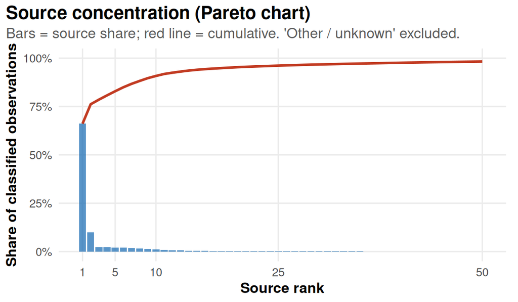

```r
ggplot(source_counts |> slice_head(n = 50), aes(x = source_rank)) +
  geom_col(aes(y = share), fill = "#2171B5", alpha = 0.75, width = 0.85) +
  geom_line(aes(y = cumulative_share), color = "#C23B22", linewidth = 1) +
  scale_x_continuous(breaks = c(1, 5, 10, 25, 50)) +
  scale_y_continuous(labels = percent, limits = c(0, 1)) +
  plot_labs(
    title    = "Source concentration (Pareto chart)",
    subtitle = "Bars = source share; red line = cumulative. 'Other / unknown' excluded.",
    x = "Source rank", y = "Share of classified observations"
  ) +
  theme_gtree()
```

The Pareto chart shows high source concentration: a small number of sources provide most of the classified observations, and the cumulative share rises quickly. As a result, any consistent bias in the largest sources can strongly affect the full dataset.

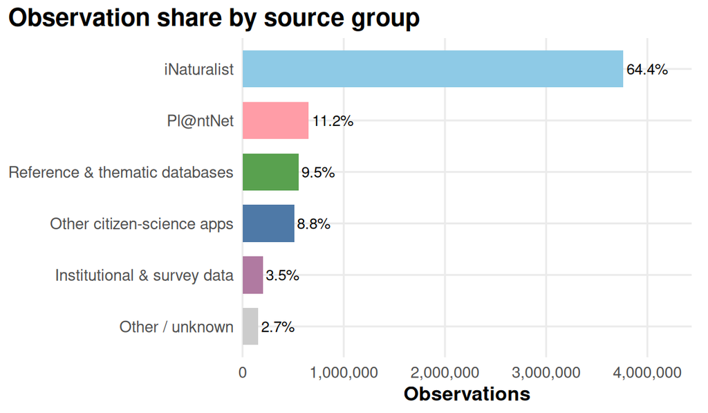

```r
ggplot(source_group_counts,
       aes(x = reorder(source_group, observations), y = observations, fill = source_group)) +
  geom_col(width = 0.72, show.legend = FALSE) +
  geom_text(aes(label = format_percent(share)), hjust = -0.08, size = 3.2) +
  coord_flip(clip = "off") +
  scale_y_continuous(labels = comma, expand = expansion(mult = c(0, 0.18))) +
  scale_fill_manual(values = source_colors) +
  plot_labs(
    title    = "Observation share by source group",
    x = NULL, y = "Observations"
  ) +
  theme_gtree()
```

The bar chart also shows that citizen-science platforms provide the largest share of observations, with iNaturalist as the main contributor. Institutional and reference sources are smaller, but they may cover regions and species that citizen-science platforms do not.

## 4.4 What Is in “Other / Unknown”?

```r
other_source_top <- df |>
  filter(source_group == "Other / unknown") |>
  count(source_raw, sort = TRUE, name = "observations") |>
  mutate(share_of_other = observations / sum(observations)) |>
  slice_head(n = 8)

n_other_sources <- n_distinct(df$source_raw[df$source_group == "Other / unknown"])
```

“Other / unknown” contains 1,426 individually named sources that did not match any keyword rule. The chart below shows the largest contributors within this heterogeneous catch-all group.

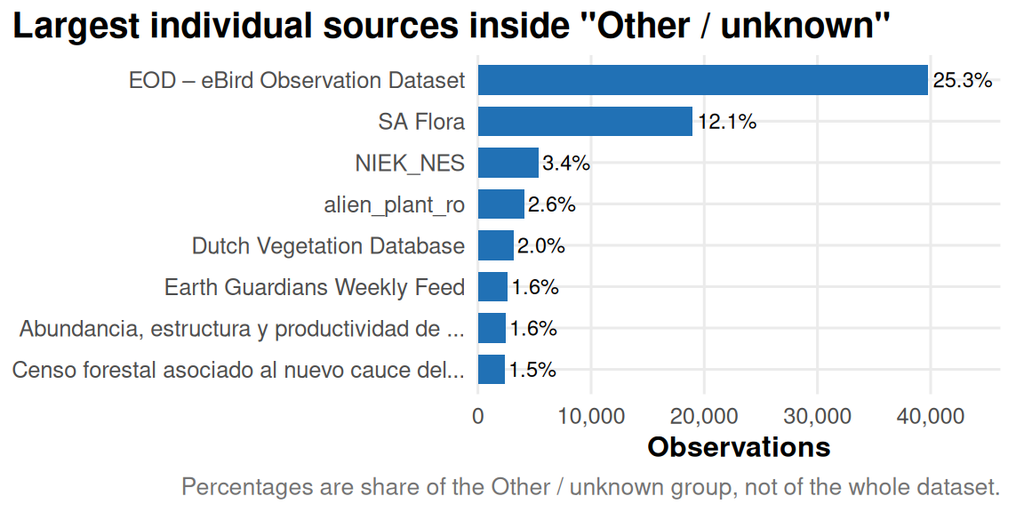

```r
ggplot(other_source_top,
       aes(x = reorder(str_trunc(source_raw, 45), observations), y = observations)) +
  geom_col(fill = "#2171B5", width = 0.72) +
  geom_text(aes(label = format_percent(share_of_other)), hjust = -0.08, size = 3.1) +
  coord_flip(clip = "off") +
  scale_y_continuous(labels = comma, expand = expansion(mult = c(0, 0.16))) +
  plot_labs(
    title    = "Largest individual sources inside \"Other / unknown\"",
    subtitle = NULL,
    x = NULL, y = "Observations",
    caption  = "Percentages are share of the Other / unknown group, not of the whole dataset."
  ) +
  theme_gtree()
```

## 4.5 Countries and Regional Coverage

- *Does source composition vary by country, or are some countries dominated by a single platform?*

When most observations from a country come from one platform, that platform strongly influences the recorded species and locations. The charts below compare the source composition of the most-observed countries and measure how diverse their sources are.

```r
top_country_values <- df |>
  count(country_code, sort = TRUE) |>
  slice_head(n = top_n_countries) |>
  pull(country_code)

country_source <- df |>
  filter(country_code %in% top_country_values) |>
  mutate(source_group_plot = ifelse(
    as.character(source_group) %in% top_source_groups,
    as.character(source_group), "Other / unknown"
  )) |>
  count(country_code, source_group_plot, name = "observations") |>
  group_by(country_code) |>
  mutate(country_total = sum(observations), share = observations / country_total) |>
  ungroup()

country_order <- country_source |>
  distinct(country_code, country_total) |>
  arrange(country_total) |>
  pull(country_code)

country_source <- country_source |>
  mutate(
    country_code     = factor(country_code, levels = country_order),
    source_group_plot = factor(source_group_plot, levels = source_group_levels)
  )

# Country code -> full name (most frequent location per code), used to build a
# readable key caption for the by-country charts (ISO codes alone are unclear).
country_name_lookup <- df |>
  filter(!is.na(location), location != "") |>
  count(country_code, location, sort = TRUE) |>
  group_by(country_code) |>
  slice_head(n = 1) |>
  ungroup() |>
  select(country_code, location)

# Builds a wrapped "US = United States; DE = Germany; ..." key for chart captions.
make_country_code_key <- function(codes) {
  key <- country_name_lookup |>
    filter(country_code %in% as.character(codes)) |>
    arrange(country_code)
  stringr::str_wrap(
    paste0("Country codes: ",
           paste0(key$country_code, " = ", key$location, collapse = "; ")),
    width = if (params$latex) 60 else 100
  )
}
```

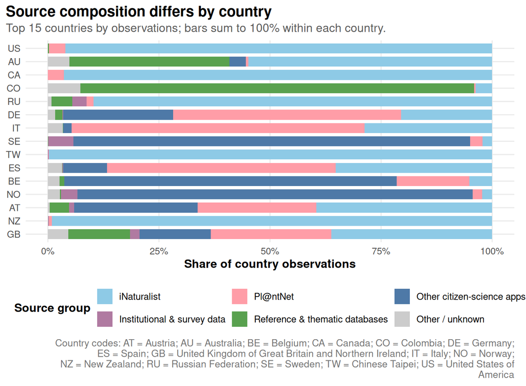

```r
ggplot(country_source, aes(x = country_code, y = share, fill = source_group_plot)) +
  geom_col(width = 0.75) +
  coord_flip() +
  scale_y_continuous(labels = percent) +
  scale_fill_manual(values = source_colors, drop = TRUE) +
  plot_labs(
    title    = "Source composition differs by country",
    subtitle = paste0(
      "Top ", top_n_countries,
      " countries by observations; bars sum to 100% within each country."
    ),
    x = NULL, y = "Share of country observations", fill = "Source group",
    caption = make_country_code_key(country_order)
  ) +
  guides(fill = guide_legend(nrow = 2, byrow = TRUE)) +
  theme_gtree() +
  theme(plot.margin = margin(6, 12, 6, 6))
```

The stacked bar chart shows large differences between countries. Some, such as the United States, rely mainly on iNaturalist, while others, including the United Kingdom and Germany, use a more balanced mix of sources. Countries dominated by one source are more exposed to its geographic and taxonomic biases.

Source diversity is measured using Shannon entropy, converted into an “effective number of source groups”. A value close to 1 means that one source group dominates.

```r
# Shannon entropy -> "effective number of source groups" per country.
shannon_diversity <- function(counts) {
  p <- counts / sum(counts)
  p <- p[p > 0]
  -sum(p * log(p))
}

country_diversity <- df |>
  count(country_code, source_group, name = "observations") |>
  group_by(country_code) |>
  summarise(
    total_observations = sum(observations),
    effective_sources  = exp(shannon_diversity(observations)),
    dominant_source    = as.character(source_group[which.max(observations)]),
    .groups = "drop"
  ) |>
  arrange(desc(total_observations)) |>
  slice_head(n = top_n_countries) |>
  mutate(country_code = factor(country_code, levels = rev(country_code)))
```

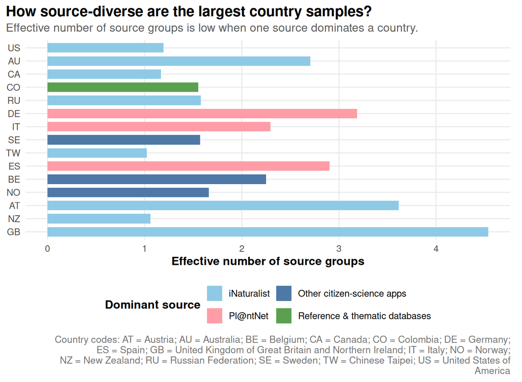

```r
ggplot(country_diversity, aes(x = country_code, y = effective_sources, fill = dominant_source)) +
  geom_col(width = 0.72) +
  coord_flip() +
  scale_fill_manual(values = source_colors, drop = TRUE) +
  plot_labs(
    title    = "How source-diverse are the largest country samples?",
    subtitle = "Effective number of source groups is low when one source dominates a country.",
    x = NULL, y = "Effective number of source groups", fill = "Dominant source",
    caption = make_country_code_key(levels(country_diversity$country_code))
  ) +
  guides(fill = guide_legend(nrow = 2, byrow = TRUE)) +
  theme_gtree() +
  theme(plot.margin = margin(6, 12, 6, 6))
```

Countries with low effective source diversity, close to 1, depend almost entirely on a single source. Their recorded species and locations therefore reflect the users and sampling patterns of that platform. Countries with higher source diversity combine several independent data sources, making their results less affected by the biases of any one platform.

## 4.6 Sources and Taxonomic Groups

- *Do different sources record different plant families, or is the source mix uniform across plant families?*

When one source type dominates, apparent geographic or temporal patterns may reflect gaps in that source’s coverage rather than real ecological differences.

```r
df <- df |> mutate(family_clean = ifelse(level1_family == "" | is.na(level1_family), "Unknown family", level1_family))

top_families <- df |>
  count(family_clean, sort = TRUE) |>
  slice_head(n = top_n_taxa) |>
  pull(family_clean)

family_source <- df |>
  filter(family_clean %in% top_families) |>
  mutate(source_group_plot = ifelse(
    as.character(source_group) %in% top_source_groups,
    as.character(source_group), "Other / unknown"
  )) |>
  count(family_clean, source_group_plot, name = "observations") |>
  group_by(family_clean) |>
  mutate(share = observations / sum(observations)) |>
  ungroup()

family_order <- family_source |>
  group_by(family_clean) |>
  summarise(total = sum(observations)) |>
  arrange(total) |>
  pull(family_clean)

family_source <- family_source |>
  mutate(
    family_clean      = factor(family_clean, levels = family_order),
    source_group_plot = factor(source_group_plot, levels = source_group_levels)
  )
```

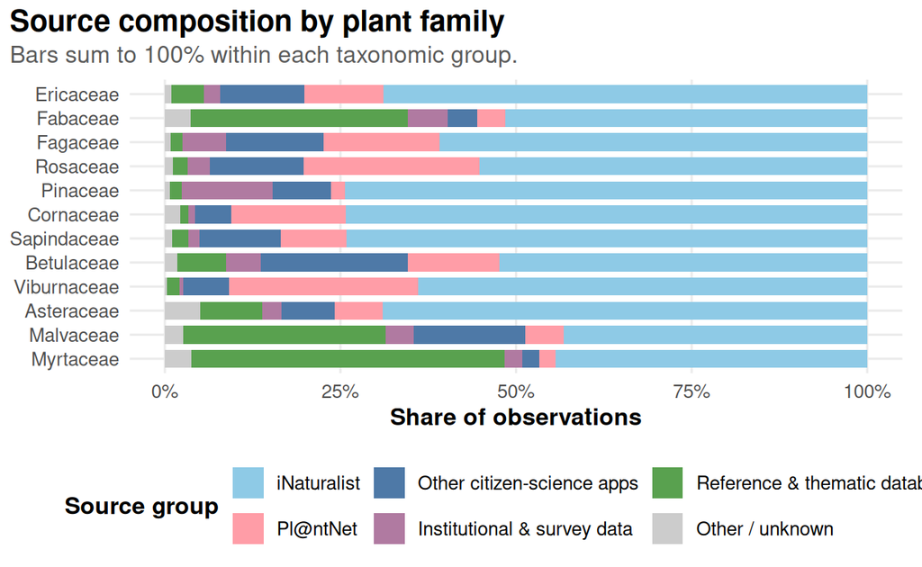

```r
ggplot(family_source, aes(x = family_clean, y = share, fill = source_group_plot)) +
  geom_col(width = 0.75) +
  coord_flip() +
  scale_y_continuous(labels = percent) +
  scale_fill_manual(values = source_colors, drop = TRUE) +
  plot_labs(
    title    = "Source composition by plant family",
    subtitle = "Bars sum to 100% within each taxonomic group.",
    x = NULL, y = "Share of observations", fill = "Source group"
  ) +
  theme_gtree()
```

The source mix differs across plant families. Some families are recorded mainly through citizen-science apps, while others depend more on institutional surveys or reference databases.

## 4.7 Geographic Footprints of Data Sources

- *Do the major sources cover the same regions, or do they each focus on different parts of the world?*

If sources are geographically complementary, the combined dataset may be broader than any single source. If they overlap heavily, gaps in one source may persist in the whole dataset.

```r
map_source_groups <- source_group_counts |>
  filter(!source_group %in% c("Other / unknown")) |>
  arrange(desc(observations)) |>
  slice_head(n = top_n_source_maps) |>
  pull(source_group) |>
  as.character()

map_data_by_source <- df |>
  filter(as.character(source_group) %in% map_source_groups,
         !is.na(latitude), !is.na(longitude),
         between(latitude, -90, 90), between(longitude, -180, 180)) |>
  group_by(source_group) |>
  group_modify(~ sample_up_to(.x, source_map_sample_n)) |>
  ungroup()

world_outline <- ggplot2::map_data("world")
world_outline_plot <- world_outline |>
  filter(region != "Antarctica")
```

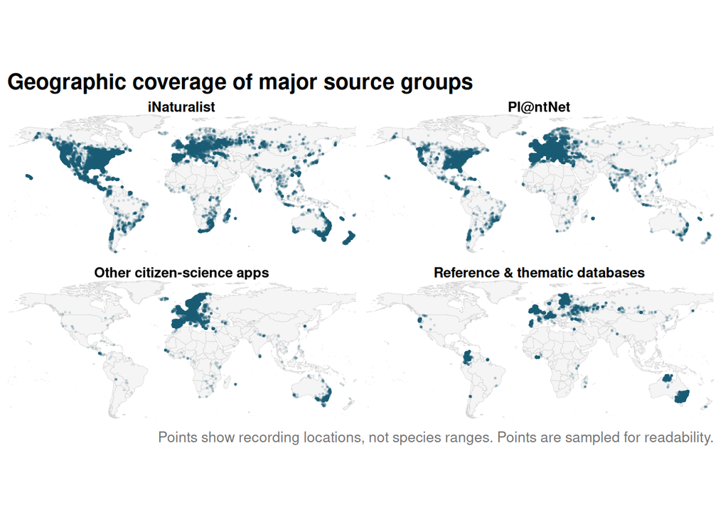

```r
ggplot() +
  geom_polygon(data = world_outline_plot, aes(x = long, y = lat, group = group),
               fill = "gray96", color = "gray82", linewidth = 0.12, inherit.aes = FALSE) +
  geom_point(data = map_data_by_source, aes(x = longitude, y = latitude),
             alpha = 0.12, size = 0.22, color = "#1F5B74") +
  facet_wrap(~ source_group, ncol = 2) +
  coord_quickmap(xlim = c(-180, 180), ylim = c(-60, 85), expand = FALSE) +
  plot_labs(
    title    = "Geographic coverage of major source groups",
    x = "Longitude", y = "Latitude",
    caption  = "Points show recording locations, not species ranges. Points are sampled for readability."
  ) +
  theme_map_gtree()
```

# 5 Temporal Development

*— Nataliia*

- *How do observation volume and geographic representation differ by observation year?*
- *Which sources are associated with the largest increases in dated observations?*

This section traces observations across the dataset time period, decomposes the pattern by source group, and examines whether the geographic footprint broadens or mainly becomes denser.

## 5.1 Observation Volume Over Time

```r
yearly_counts <- df |>
  filter(year >= start_year, year <= end_year) |>
  count(year, name = "observations") |>
  right_join(tibble(year = start_year:end_year), by = "year") |>
  mutate(observations    = ifelse(is.na(observations), 0L, observations)) |>
  arrange(year) |>
  mutate(absolute_change = observations - lag(observations))

growth_summary    <- yearly_counts |> filter(!is.na(absolute_change))
strongest_growth  <- growth_summary |> slice_max(absolute_change, n = 1, with_ties = FALSE)
strongest_decline <- growth_summary |> slice_min(absolute_change, n = 1, with_ties = FALSE)

first_year_count <- yearly_counts$observations[yearly_counts$year == start_year]
last_year_count  <- yearly_counts$observations[yearly_counts$year == end_year]
overall_change   <- (last_year_count - first_year_count) / first_year_count
```

Between 2015 and 2024, observations changed from **193,601** to **792,050**, an overall change of **309.1%**.

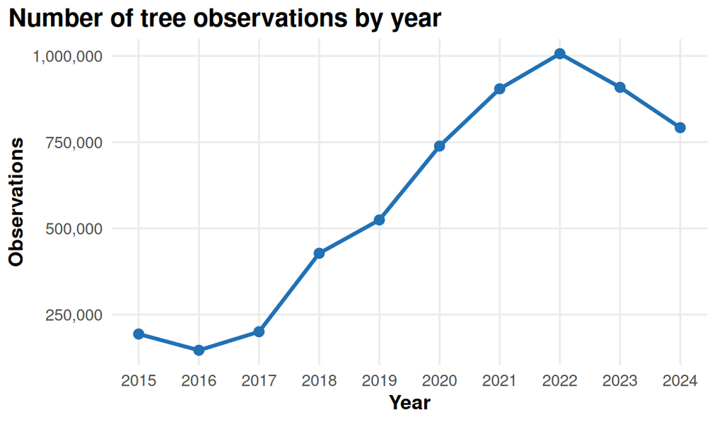

```r
ggplot(yearly_counts, aes(x = year, y = observations)) +
  geom_line(color = "#2171B5", linewidth = 1.1) +
  geom_point(color = "#2171B5", size = 2.4) +
  scale_x_continuous(breaks = start_year:end_year) +
  scale_y_continuous(labels = comma) +
  plot_labs(title = "Number of tree observations by year", x = "Year", y = "Observations") +
  theme_gtree()
```

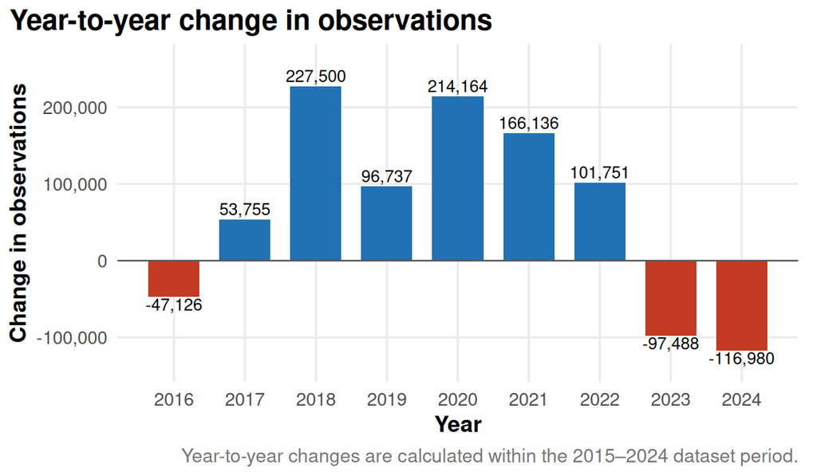

```r
ggplot(growth_summary, aes(x = year, y = absolute_change, fill = absolute_change >= 0)) +
  geom_col(width = 0.72, show.legend = FALSE) +
  geom_hline(yintercept = 0, color = "gray35", linewidth = 0.4) +
  geom_text(
    aes(label = format_number(absolute_change)),
    vjust = ifelse(growth_summary$absolute_change >= 0, -0.35, 1.15),
    size  = 3.1
  ) +
  scale_x_continuous(breaks = start_year:end_year) +
  scale_y_continuous(labels = comma, expand = expansion(mult = c(0.12, 0.16))) +
  scale_fill_manual(values = c("TRUE" = "#2171B5", "FALSE" = "#C23B22")) +
  plot_labs(
    title   = "Year-to-year change in observations",
    x = "Year", y = "Change in observations",
    caption = paste0("Year-to-year changes are calculated within the ", start_year, "–", end_year, " dataset period.")
  ) +
  theme_gtree()
```

The strongest growth occurs in **2018** (+227,500 observations), and the strongest decline in **2024** (-116,980).

## 5.2 Which Sources Drive the Temporal Trend?

```r
# Observations per year and source group
source_year <- df |>
  filter(year >= start_year, year <= end_year) |>
  mutate(source_group_plot = ifelse(
    as.character(source_group) %in% top_source_groups,
    as.character(source_group), "Other / unknown"
  )) |>
  count(year, source_group_plot, name = "observations") |>
  right_join(
    expand.grid(year = start_year:end_year,
                source_group_plot = source_group_levels),
    by = c("year", "source_group_plot")
  ) |>
  mutate(observations = ifelse(is.na(observations), 0L, observations)) |>
  group_by(year) |>
  mutate(
    share = observations / sum(observations),
    share = ifelse(is.nan(share), 0, share)
  ) |>
  ungroup() |>
  mutate(source_group_plot = factor(source_group_plot, levels = source_group_levels))
```

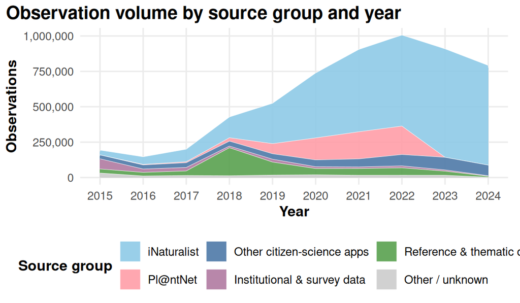

```r
ggplot(source_year, aes(x = year, y = observations, fill = source_group_plot)) +
  geom_area(alpha = 0.9, linewidth = 0.15, color = "white") +
  scale_x_continuous(breaks = start_year:end_year) +
  scale_y_continuous(labels = comma) +
  scale_fill_manual(values = source_colors, drop = TRUE) +
  plot_labs(
    title    = "Observation volume by source group and year",
    x = "Year", y = "Observations", fill = "Source group"
  ) +
  theme_gtree()
```

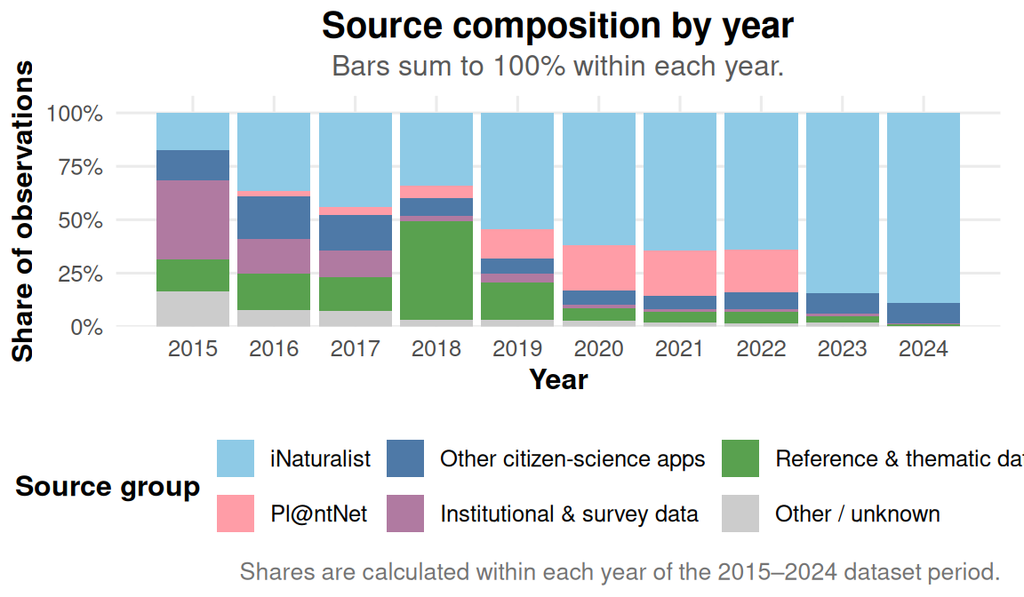

```r
ggplot(source_year, aes(x = year, y = share, fill = source_group_plot)) +
  geom_col(width = 0.9) +
  scale_x_continuous(breaks = start_year:end_year) +
  scale_y_continuous(labels = percent, expand = expansion(mult = c(0, 0.08))) +
  scale_fill_manual(values = source_colors, drop = TRUE) +
  plot_labs(
    title    = "Source composition by year",
    subtitle = "Bars sum to 100% within each year.",
    x = "Year", y = "Share of observations", fill = "Source group",
    caption  = paste0("Shares are calculated within each year of the ", start_year, "–", end_year, " dataset period.")
  ) +
  theme_gtree() +
  # Centre title and subtitle over the plotting panel so they clear the y-axis label.
  theme(
    plot.title.position = "panel",
    plot.title    = element_text(hjust = 0.5),
    plot.subtitle = element_text(hjust = 0.5)
  )
```

The year-by-year source share view shows whether the source mix is shifting over time. If one source group’s share is growing while others shrink, the dataset’s overall character is changing — even if total volume increases. A stable composition would suggest that all sources are growing at roughly the same rate.

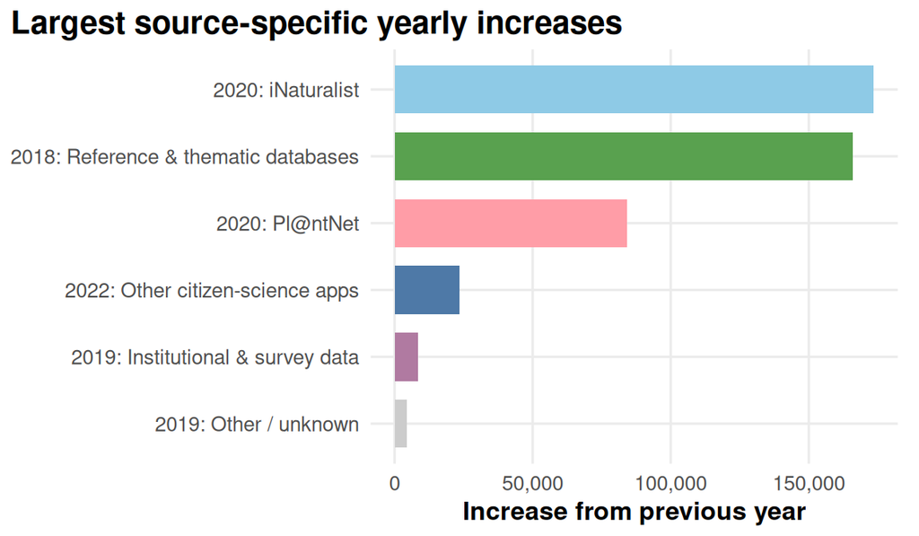

```r
largest_source_growth <- source_year |>
  arrange(source_group_plot, year) |>
  group_by(source_group_plot) |>
  mutate(source_change = observations - lag(observations)) |>
  filter(!is.na(source_change)) |>
  slice_max(source_change, n = 1, with_ties = FALSE) |>
  mutate(label = paste0(year, ": ", source_group_plot)) |>
  ungroup()

ggplot(largest_source_growth,
       aes(x = reorder(label, source_change), y = source_change, fill = source_group_plot)) +
  geom_col(width = 0.72, show.legend = FALSE) +
  coord_flip() +
  scale_y_continuous(labels = comma) +
  scale_fill_manual(values = source_colors, drop = TRUE) +
  plot_labs(title = "Largest source-specific yearly increases", x = NULL, y = "Increase from previous year") +
  theme_gtree()
```

The chart above highlights the single largest year-over-year jumps for each source group, making it easy to identify which platforms drove the biggest surges in data volume and when those surges occurred.

## 5.3 Geographic Coverage Over Time

This subsection examines how the geographic reach of observations dated from 2015 to 2024 differs over time. It compares the first observation year represented for each country within this period and maps observation locations at selected snapshot years.

```r
country_year <- df |>
  filter(year >= start_year, year <= end_year) |>
  count(year, country_code, name = "observations")

country_first_year <- country_year |>
  group_by(country_code) |>
  summarise(first_observed_year = min(year), .groups = "drop")
```

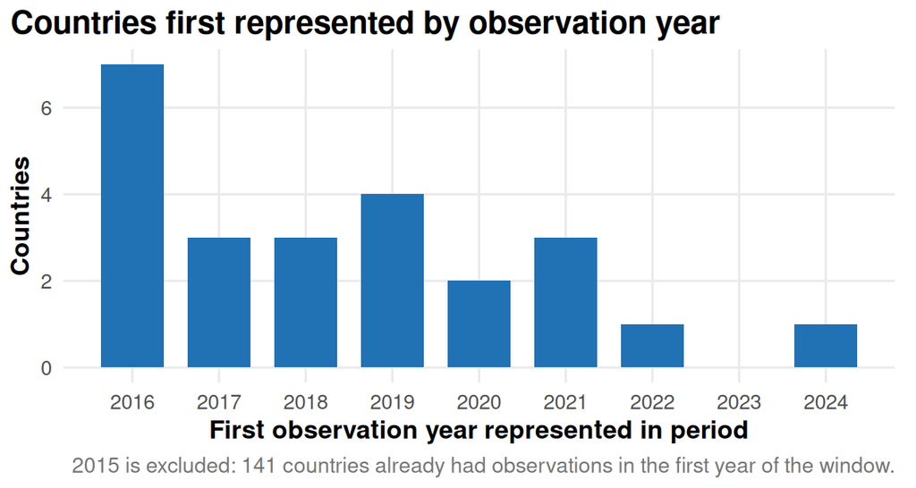

```r
new_countries <- country_first_year |>
  filter(first_observed_year > start_year) |>
  count(first_observed_year, name = "new_countries") |>
  right_join(tibble(first_observed_year = (start_year + 1):end_year), by = "first_observed_year") |>
  mutate(new_countries = ifelse(is.na(new_countries), 0L, new_countries))

countries_at_start <- sum(country_first_year$first_observed_year == start_year)

ggplot(new_countries, aes(x = first_observed_year, y = new_countries)) +
  geom_col(fill = "#2171B5", width = 0.72) +
  scale_x_continuous(breaks = (start_year + 1):end_year) +
  scale_y_continuous(labels = comma) +
  plot_labs(
    title   = "Countries first represented by observation year",
    x = "First observation year represented in period", y = "Countries",
    caption = paste0(
      start_year, " is excluded: ", countries_at_start,
      " countries already had observations in the first year of the window."
    )
  ) +
  theme_gtree()
```

This chart shows when countries first appear among the observations dated within the selected period. A declining count suggests that later observation years add relatively few countries not already represented by earlier-dated records.

The maps below show observation locations at four snapshot years, revealing whether records spread into new regions or simply become denser in existing ones.

```r
snapshot_years_valid <- snapshot_years[snapshot_years >= start_year & snapshot_years <= end_year]

map_data_by_year <- df |>
  filter(year %in% snapshot_years_valid,
         !is.na(latitude), !is.na(longitude),
         between(latitude, -90, 90), between(longitude, -180, 180)) |>
  group_by(year) |>
  group_modify(~ sample_up_to(.x, world_map_sample_n)) |>
  ungroup()
```

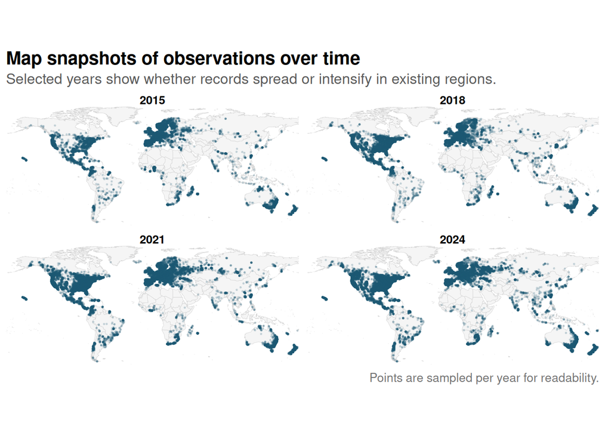

```r
ggplot() +
  geom_polygon(data = world_outline_plot, aes(x = long, y = lat, group = group),
               fill = "gray96", color = "gray82", linewidth = 0.12, inherit.aes = FALSE) +
  geom_point(data = map_data_by_year, aes(x = longitude, y = latitude),
             alpha = 0.15, size = 0.22, color = "#1F5B74") +
  facet_wrap(~ year, ncol = 2) +
  coord_quickmap(xlim = c(-180, 180), ylim = c(-60, 85), expand = FALSE) +
  plot_labs(
    title    = "Map snapshots of observations over time",
    subtitle = "Selected years show whether records spread or intensify in existing regions.",
    x = "Longitude", y = "Latitude",
    caption  = "Points are sampled per year for readability."
  ) +
  theme_map_gtree()
```

Comparing the four snapshot years shows that the geographic footprint of the dated observations was already broadly established early in the period: North America, Europe, and parts of Oceania and South America are visible from the first panel. Later panels show a clear increase in point density within these same regions, but comparatively little expansion into previously unrepresented areas such as central Africa, Central Asia, or the Amazon interior. Within the observation-year window, the pattern is therefore more consistent with intensification than with geographic expansion.

# 6 Taxonomic Composition and Geographic Patterns

## 6.1 Species observed in this dataset

*— Anna*

What are the different tree families referenced in this dataset?

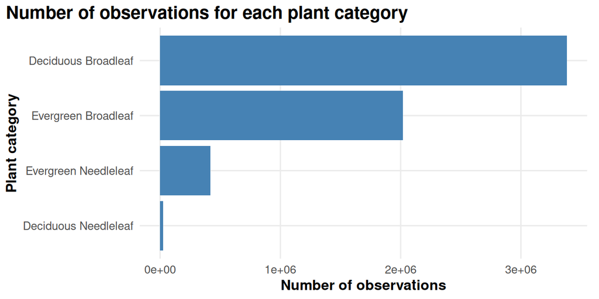

Observation counts for the four foliage categories in GlobalGeoTree.

```r
level0_count <- data %>% count(level0, sort = TRUE)

ggplot(level0_count, aes(x = reorder(level0, n), y = n)) + geom_col(fill = "steelblue") + coord_flip() + plot_labs( x = "Plant category", y = "Number of observations", title = "Number of observations for each plant category" ) + theme_gtree()
```

Definition of each tree category:

- Evergreen Needleleaf: An evergreen needleleaf refers to woody vegetation that retains needle-like or scale-like foliage year-round
- Evergreen Broadleaf: An evergreen broadleaf is a plant or tree that has wide, flat leaves (rather than needles or scales) and retains its foliage year-round
- Deciduous Broadleaf: a diverse group of flowering plants (angiosperms) characterised by flat leaves that are shed annually before winter (Oak, Maple, Beech, Birch, and Poplar/Aspen)
- Deciduous Needleleaf: a unique group of conifers that, unlike their evergreen counterparts, shed all their needles annually in the autumn (rare trees)

Deciduous Broadleaf is the largest foliage category among observations in this dataset. Deciduous Needleleaf accounts for a much smaller share and appears in more geographically restricted areas. These values describe the composition of GlobalGeoTree observations rather than the worldwide abundance of each foliage type.

What are the different taxonomic families represented in this dataset and in which proportion are they represented?

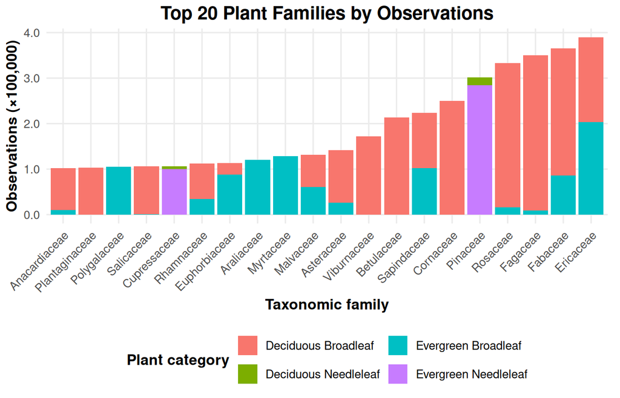

The 20 taxonomic families with the largest observation counts in the dataset.

```r
# The 20 families with the most observations overall.  Rank on the family total,
# not on (level0, family) pairs: a family split across two categories would be
# ranked on each half and could drop out despite a large total.
top20_families <- data %>%
  count(level1_family, sort = TRUE) %>%
  slice_head(n = 20)

# Category breakdown within those 20 families — one row per bar segment.
top20 <- data %>%
  filter(level1_family %in% top20_families$level1_family) %>%
  count(level0, level1_family)

ggplot(
  top20,
  aes(
    x = reorder(level1_family, n, FUN = sum),
    y = n,
    fill = level0
  )
) +
  geom_col() +
  plot_labs(
    x = "Taxonomic family",
    y = "Observations (×100,000)",
    title = "Top 20 Plant Families by Observations",
    fill = "Plant category"
  ) +
  scale_y_continuous(
    labels = scales::label_number(scale = 1 / 100000, accuracy = 0.1)
  ) +
  theme_gtree() +
  # Four foliage names on one row overflow the figure width, so wrap to two.
  guides(fill = guide_legend(nrow = 2)) +
  # Centre the title over the plotting panel so it clears the y-axis label.
  theme(
    axis.text.x = element_text(angle = 45, hjust = 1),
    plot.title.position = "panel",
    plot.title  = element_text(hjust = 0.5)
  )
```

## 6.2 Geographical distribution of the observations

*— Anna*

How are the trees distributed depending on the latitude?

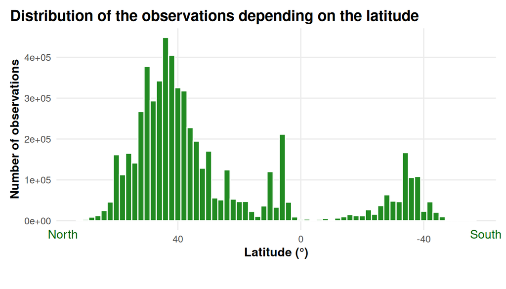

```r
ggplot(data, aes(x = latitude)) + geom_histogram(binwidth = 2, fill = "forestgreen", color = "white") + scale_x_reverse() + plot_labs( title = "Distribution of the observations depending on the latitude", x = "Latitude (°)", y = "Number of observations" ) + annotate( "text", x = min(data$latitude, na.rm = TRUE),
    y = -Inf,
    label = "South",
    vjust = 1,
    hjust = 0,
    col="darkgreen"
  ) +
  annotate(
    "text",
    x = max(data$latitude, na.rm = TRUE), y = -Inf, label = "North", vjust = 1, hjust = 1, col="darkgreen" ) + theme_gtree() + coord_cartesian(clip = "off") + theme( plot.margin = margin(10, 10, 30, 10) )
```

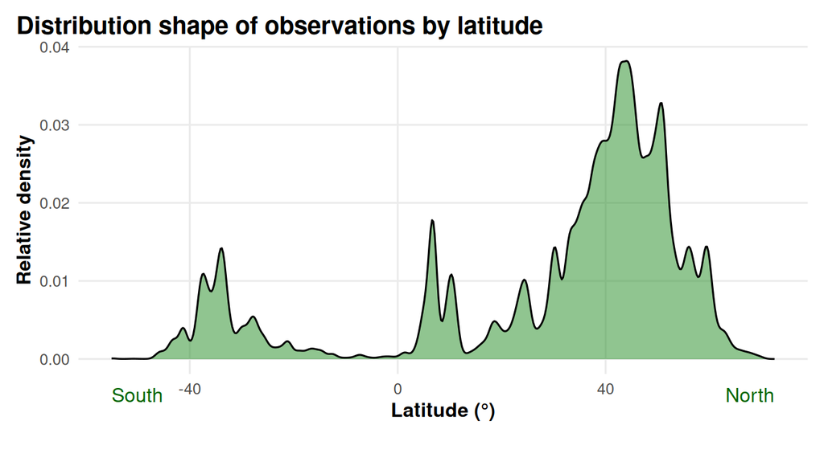

```r
# density curve

ggplot(data, aes(x = latitude)) + geom_density(fill = "forestgreen", alpha = 0.5) + plot_labs( title = "Distribution shape of observations by latitude", x = "Latitude (°)", y = "Relative density" ) + theme_gtree() + annotate( "text", x = min(data$latitude, na.rm = TRUE),
    y = -Inf,
    label = "South",
    vjust = 2,
    hjust = 0,
    col="darkgreen"
  ) +
  annotate(
    "text",
    x = max(data$latitude, na.rm = TRUE), y = -Inf, label = "North", vjust = 2, hjust = 1, col="darkgreen" ) + coord_cartesian(clip = "off") + theme( plot.margin = margin(10, 10, 30, 10) )
```

The histogram preserves absolute observation counts in each latitude interval, while the density curve emphasises the overall distribution shape. Both show substantially more recorded observations in the Northern Hemisphere, which may reflect differences in land area and sampling effort as well as tree distribution.

Coarser aggregations are also often used in ecological studies, because 5° latitudinal bands carry a sufficient amount of information without showing too much noise.

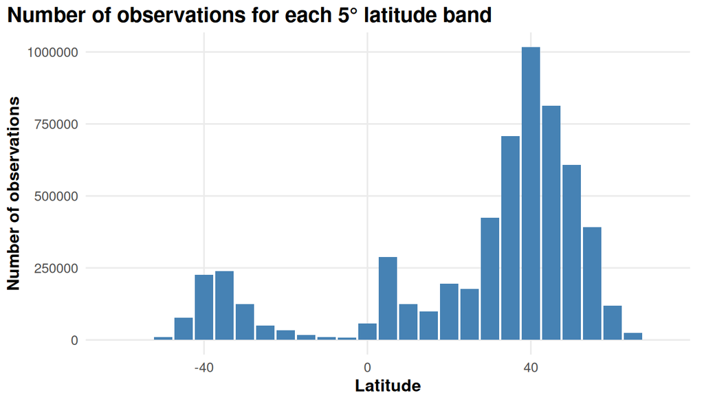

```r
lat_band <- data %>% mutate(lat_bin = floor(latitude / 5) * 5) %>% count(lat_bin)

ggplot(lat_band, aes(x = lat_bin, y = n)) + geom_col(fill = "steelblue") + plot_labs( title = "Number of observations for each 5° latitude band", x = "Latitude", y = "Number of observations" ) + theme_gtree()
```

Binned into 5° bands, the distribution shows the same pattern as the histogram above: recorded observations concentrate heavily in the northern temperate latitudes.

We usually take 5° slices because they are narrow enough to reveal local tendencies and geographical patterns (climatic gradients, biodiversity, species distribution, and so on), but wide enough to avoid the noise and uninformative detail that finer bands introduce.

## 6.3 Geographical observations of species

*— Anna*

How does latitude influence the different species observed (latitude and species richness)?

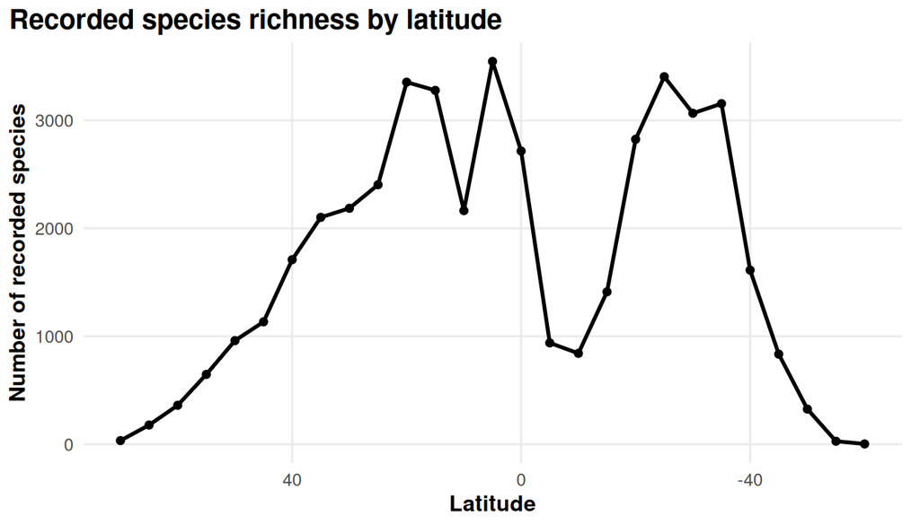

```r
richness <- data %>% mutate(lat_bin = floor(latitude / 5) * 5) %>% group_by(lat_bin) %>% summarise(species_richness = n_distinct(species_key))

ggplot(richness, aes(lat_bin, species_richness)) + geom_line(linewidth = 1) + geom_point() + plot_labs( title = "Recorded species richness by latitude", x = "Latitude", y = "Number of recorded species" ) + theme_gtree()+ scale_x_reverse()
```

We see here that the maximum species richness is very close in the two hemispheres, but that the distribution is broader in the Northern Hemisphere than in the Southern Hemisphere (partly because trees grow at higher latitudes in the Northern Hemisphere than in the Southern Hemisphere). Similar environmental conditions can be found in the two hemispheres but they are not spread following the same pattern.

How does longitude influence the different species observed (longitude and species richness)?

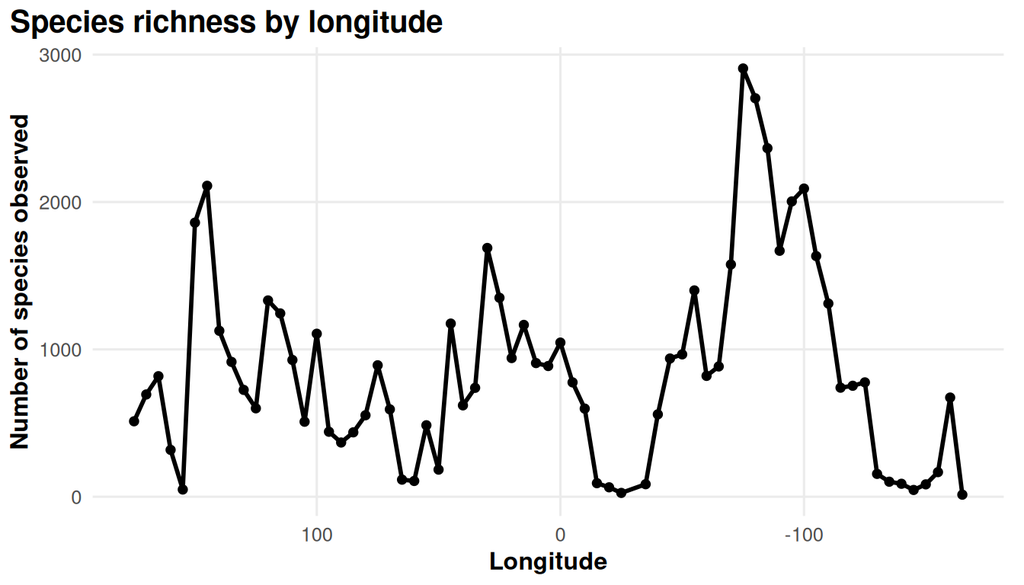

```r
richness_long <- data %>% mutate(long_bin = floor(longitude / 5) * 5) %>% group_by(long_bin) %>% summarise(species_richness = n_distinct(species_key))

ggplot(richness_long, aes(long_bin, species_richness)) + geom_line(linewidth = 1) + geom_point() + plot_labs( title = "Species richness by longitude", x = "Longitude", y = "Number of species observed" ) + theme_gtree()+ scale_x_reverse()
```

Areas with high recorded species richness correspond to continental areas, but little more can be concluded from longitude alone.

What is the local recorded species richness across the world?

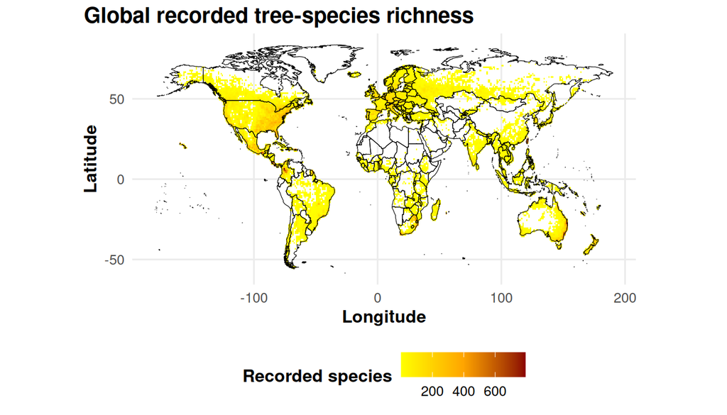

Recorded species richness per 1° grid cell. Counts use all observations; the map shows recorded richness rather than estimated biological richness.

```r
richness_grid <- data %>%
  mutate( lat_bin = floor(latitude / 1) * 1, long_bin = floor(longitude / 1) * 1 ) %>% group_by(lat_bin, long_bin) %>% summarise( richness = n_distinct(species_key), .groups = "drop" )

world <- if (exists("world_outline_plot")) {
  world_outline_plot
} else {
  ggplot2::map_data("world") |>
    filter(region != "Antarctica")
}

ggplot() + geom_tile( data = richness_grid, aes( x = long_bin + 0.5, y = lat_bin + 0.5, fill = richness ) ) + geom_polygon( data = world, aes(long, lat, group = group), fill = NA, color = "black", linewidth = 0.2 ) + scale_fill_gradientn( colours = c( "yellow", "orange", "darkred" ), name = "Recorded species" ) + coord_fixed(1.3) + plot_labs( title = "Global recorded tree-species richness", x = "Longitude", y = "Latitude" ) + theme_gtree()
```

Within sampled areas, many grid cells show similar recorded richness, while the species involved vary geographically. Observation effort also varies strongly between cells, so the map should not be read as showing homogeneous underlying biodiversity.

How are the different tree species distributed depending on the latitude? Here, we only check for the most represented species.

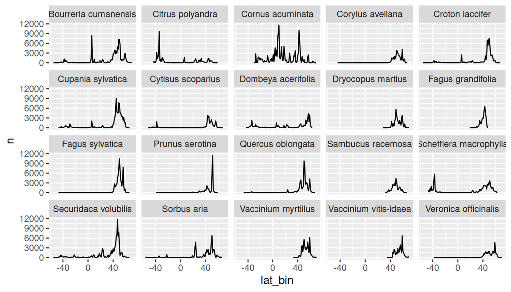

```r
# latitude distribution of the 20 most frequent species
top_species <- data %>% count(level3_species, sort = TRUE) %>% slice_head(n = 20)

lat_species <- data %>% filter(level3_species %in% top_species$level3_species) %>% mutate(lat_bin = floor(latitude)) %>% count(level3_species, lat_bin)

ggplot(lat_species, aes(lat_bin, n)) + geom_line() + facet_wrap(~level3_species)
```

With this figure, we see that the most represented species in this dataset have different world distributions. Most are mainly present in the Northern Hemisphere, but some are also present in the Southern Hemisphere (such as *Dombeya acerifolia*), and some are almost evenly present in the two hemispheres, such as *Cornus acuminata*.

Another representation could be a heatmap representing the species depending on the latitude:

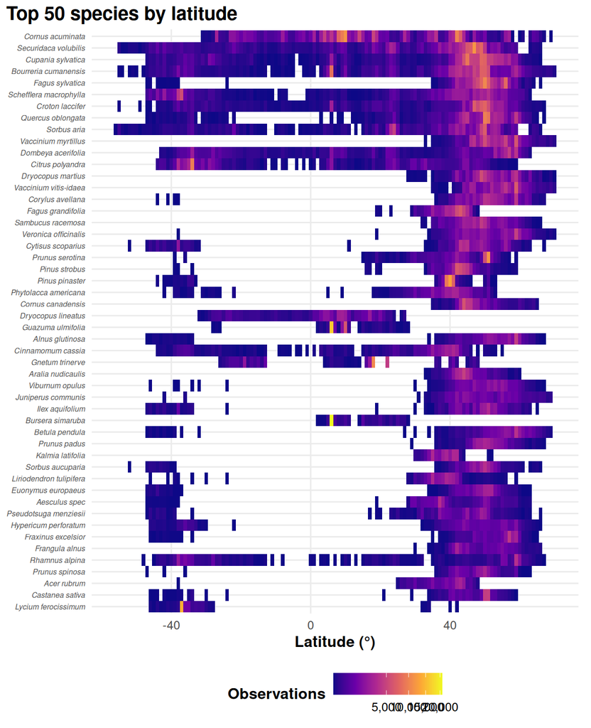

Figure 1: Observation counts by latitude for the 50 most recorded species.

```r
top50 <- data %>% count(level3_species, sort = TRUE) %>% slice_head(n = 50)

heat <- data %>% filter(level3_species %in% top50$level3_species) %>% mutate(lat_bin = floor(latitude)) %>% count(level3_species, lat_bin)

# Rank species on their total, not on the mean count per latitude bin, which is
# what reorder() would default to.
ggplot(heat, aes(x = lat_bin, y = reorder(level3_species, n, FUN = sum), fill = n)) +
  geom_tile() +
  scale_fill_viridis_c(option = "C", transform = "sqrt", labels = scales::comma) +
  plot_labs(
    x = "Latitude (°)",
    y = NULL,
    fill = "Observations",
    title = "Top 50 species by latitude"
  ) +
  theme_gtree() +
  theme(axis.text.y = element_text(size = 6, face = "italic"))
```

Figure 1 shows again that most species are present mostly in the Northern Hemisphere, but some can also be present in both hemispheres, or only in the Southern Hemisphere or near the equator (*Guazuma ulmifolia*, a tree largely present in Latin America and very rare in other areas).

The boxplot below compares the latitudinal spread of the twenty most recorded families, ordered by median latitude, so that families centred on temperate bands can be separated from those reaching towards the equator.

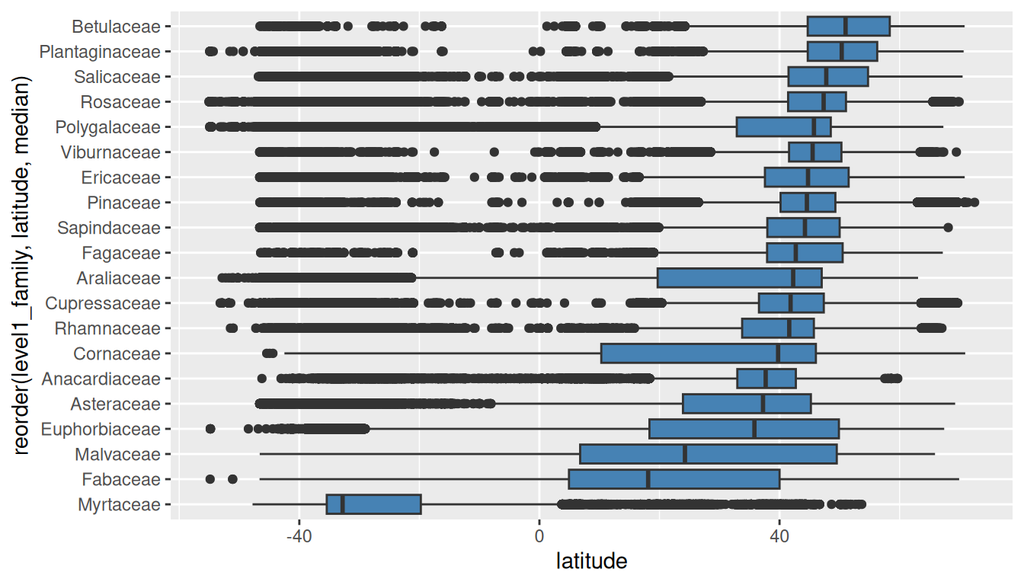

```r
top20_family <- data %>% count(level1_family, sort = TRUE) %>% slice_head(n = 20)

ggplot( data %>% filter(level1_family %in% top20_family$level1_family), aes(x = reorder(level1_family, latitude, median), y = latitude) ) + geom_boxplot(fill = "steelblue") + coord_flip()
```

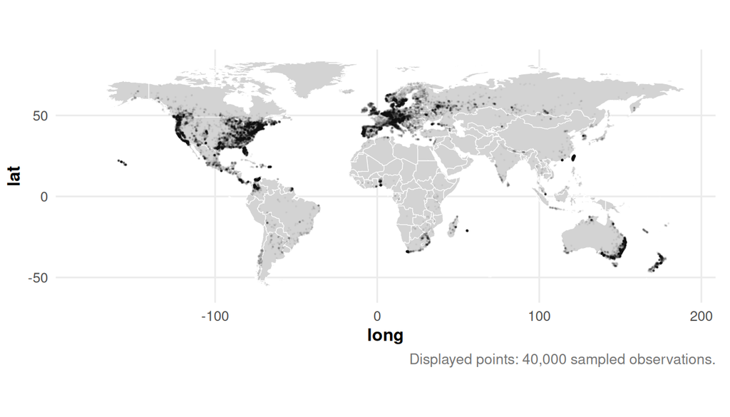

```r
data_sample <- df_world_map_sample

ggplot(data_sample, aes(longitude, latitude)) +
  geom_polygon(data = world, aes(long, lat, group = group), fill = "lightgrey", color = "white", linewidth = 0.2, inherit.aes = FALSE) +
  geom_point(alpha = 0.03, size = 0.05) +
  coord_fixed() +
  plot_labs(caption = paste("Displayed points:", format_number(nrow(data_sample)), "sampled observations.")) +
  theme_gtree()
```

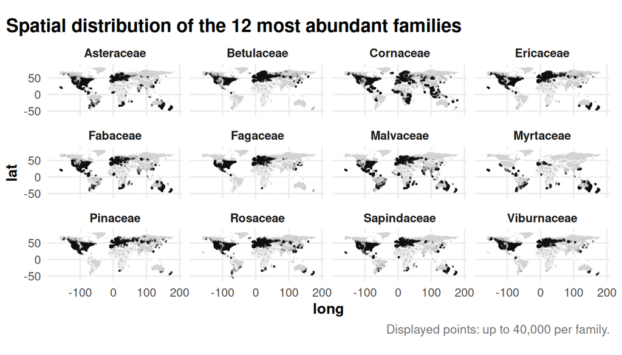

```r
# one map for each family (20 first families)
top_families <- data %>% count(level1_family, sort = TRUE) %>% slice_head(n = 12) %>% pull(level1_family)

data_top <- df_world_map_base %>%
  filter(level1_family %in% top_families) %>%
  group_by(level1_family) %>%
  group_modify(~ sample_up_to(.x, world_map_sample_n)) %>%
  ungroup()

ggplot(data_top, aes(longitude, latitude)) +
  geom_polygon(data = world, aes(long, lat, group = group), fill = "lightgrey", color = "white", linewidth = 0.2, inherit.aes = FALSE) +
  geom_point(alpha = 0.03, size = 0.05) +
  facet_wrap(~ level1_family) + coord_fixed() + theme_gtree() +
  plot_labs(
    title = "Spatial distribution of the 12 most abundant families",
    caption = paste("Displayed points: up to", format_number(world_map_sample_n), "per family.")
  )
```

On this visualisation, we can see the distribution of the different taxonomic families across the world:

- Some families are very widely spread across the world, such as the Asteraceae. This family contains a very large number of different species that live in temperate areas and can survive a range of non-extreme conditions.
- Other families are observed in more restricted areas, such as the Ericaceae and Pinaceae. These families are well adapted to cold and inhospitable places such as the tundra and boreal forests, or to places at high altitude.

# 7 Worldwide Distribution of the Data

*— Camille*

How are observations distributed globally, and what does this reveal about sampling bias and taxonomic diversity? This section addresses four guiding questions:

1. Where are observations geographically concentrated, and does the coverage reflect ecological reality or observer activity?
2. How does the distribution of foliage types vary across latitudes and continents?
3. How does taxonomic richness compare across continents once differences in sampling effort are accounted for?
4. Has the spatial coverage of the dataset expanded or merely intensified over the years?

This distribution shapes how the rest of the dataset should be interpreted: an over-representation of certain regions may reflect sampling bias — the activity of contributors in the field — rather than the true state of global tree biodiversity.

## 7.1 Pre-Processing

Observations are grouped by continent rather than by country, so that comparisons are not fragmented across more than 210 individual countries. The continent for each observation was derived by spatially joining the point coordinates (longitude, latitude) with a world countries shapefile (rnaturalearth). This relies on administrative boundaries, which do not always align with the geography relevant to this study, so two adjustments were necessary:

- Russia is administratively classified as a single entity, but spans two geographical continents. Observations were reassigned to Europe or Asia based on the conventional Ural Mountains boundary (60°E longitude).
- Réunion, despite being a French overseas territory, is geographically located in the Indian Ocean off the African coast, and was therefore reassigned to Africa rather than being grouped with other European territories.

Observations for which no continent could be determined, as well as those located over open ocean (e.g., isolated island territories not covered by the country shapefile), were excluded from the dataset.

The resulting dataset, with the added continent column, is previewed in Table 1.

```r
df_preview <- head(df) |>
  select(sample_id, country_code, level0, level1_family, level2_genus,
         level3_species, source, year, continent)
if (params$latex) {
  kableExtra::kbl(df_preview, booktabs = TRUE, longtable = FALSE) |>
    kableExtra::kable_styling(latex_options = c("scale_down", "hold_position"))
} else {
  kable(df_preview)
}
```

| sample_id | country_code | level0 | level1_family | level2_genus | level3_species | source | year | continent |
| --- | --- | --- | --- | --- | --- | --- | --- | --- |
| 1 | MW | Evergreen Broadleaf | Acanthaceae | Anisotes | Anisotes formosissimus | iNaturalist Research-grade Observations | 2024 | Africa |
| 2 | MZ | Evergreen Broadleaf | Acanthaceae | Anisotes | Anisotes formosissimus | iNaturalist Research-grade Observations | 2018 | Africa |
| 3 | MZ | Evergreen Broadleaf | Acanthaceae | Anisotes | Anisotes sessiliflorus | iNaturalist Research-grade Observations | 2022 | Africa |
| 4 | MZ | Evergreen Broadleaf | Acanthaceae | Anisotes | Anisotes sessiliflorus | iNaturalist Research-grade Observations | 2015 | Africa |
| 6 | KE | Evergreen Broadleaf | Acanthaceae | Avicennia | Avicennia spec | naturgucker | 2023 | Africa |
| 9 | NG | Evergreen Broadleaf | Acanthaceae | Avicennia | Avicennia spec | Flora of Coastal Environment in Cross-River State, Nigeria | 2019 | Africa |

Table 1: An overview of the first few rows of the dataset

To ensure visual consistency throughout this section, each continent is assigned a fixed colour, shown in Figure 2. This colour scheme is derived from the Okabe-Ito palette, chosen for its colour-blind-friendly properties, and is applied consistently across all subsequent maps and charts to facilitate comparison between figures.

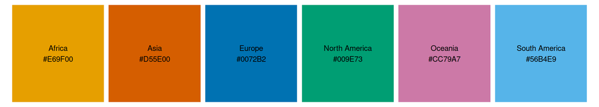

Figure 2: Colour scheme used to represent the continents in the following figures

```r
continent_colors <- c(
  "Africa"        = "#E69F00",  # orange
  "Asia"          = "#D55E00",  # red-orange
  "Europe"        = "#0072B2",  # blue
  "North America" = "#009E73",  # green
  "South America" = "#56B4E9",  # light blue
  "Oceania"       = "#CC79A7"   # purple
)


ggplot(
  data.frame(
    continent = names(continent_colors),
    color = continent_colors
  ),
  aes(x = continent, y = 1, fill = continent)
) +

  geom_tile(width = 0.95, height = 0.8) +

  scale_fill_manual(values = continent_colors) +

  geom_text(
    aes(label = paste0(continent, "\n", color)),
    size = 3.2, vjust = 0.5
  ) +

  theme_void() +

  theme(legend.position = "none")
```